```r
library(tidyverse)
```

```r
library(qqman)
library(seqinr)
```

# Quality Control

### Identification of individuals with elevated missing data rates or outlying heterozygosity rates

We want to filter out all samples that has a high rate of missing data, since that can be due low DNA quality or concentration. Furthermore, we want to filter samples with either high or low heterozygosity rate. Low heterozygosity could be due to imbreeding and high heterozygosity could be due to contamiation of the sample. Both of these will bias the result.

To identify missing data rates, we run the following command from the shell prompt:

`plink --bfile eye_color --missing --allow-no-sex --out eyecolor`

To identify heterozygosity rate, we run the following command:

`plink --bfile eye_color --het --allow-no-sex --out eyecolor`

- Het = (NM − Hom)/NM

Now, in R, we make a combined dataframe with the missing SNPs and the heterozygosity rates.

```r
d_miss <- read.table("eyecolor.imiss",header=T)
d_het <- read.table("eyecolor.het",header=T)
d <- inner_join(d_miss,d_het)
d <- d %>%
    mutate(Het = (N.NM.-O.HOM.)/N.NM.)

head(d)
```

```
##    FID  IID MISS_PHENO N_MISS N_GENO   F_MISS O.HOM. E.HOM.  N.NM.        F
## 1 1010 1010          Y 417559 958847 0.435500 355012 353100 522943 0.011510
## 2 1013 1013          Y   1589 958847 0.001657 622171 618900 897402 0.011880
## 3 1020 1020          Y   3555 958847 0.003708 620700 617700 895619 0.010850
## 4 1022 1022          Y  23735 958847 0.024750 609152 605200 877300 0.014590
## 5 1024 1024          Y  23896 958847 0.024920 606768 605000 876929 0.006683
## 6 1026 1026          Y  23264 958847 0.024260 611711 605300 877569 0.023400
##         Het
## 1 0.3211268
## 2 0.3066976
## 3 0.3069598
## 4 0.3056514
## 5 0.3080763
## 6 0.3029483
```

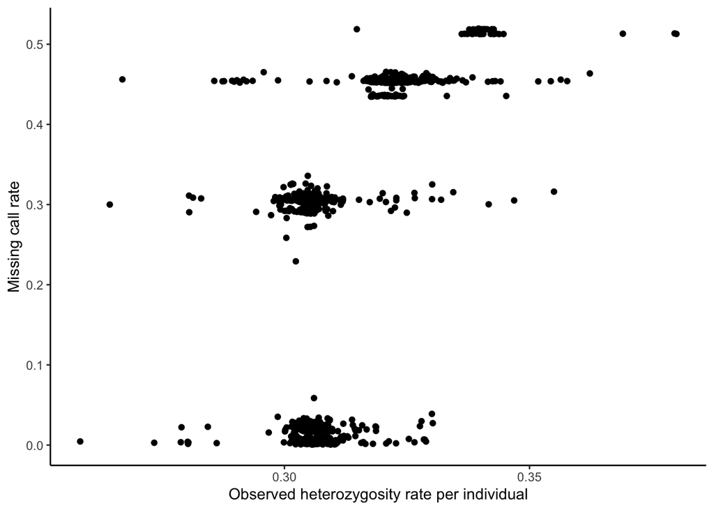

```r
ggplot(data = d) +
    geom_point(aes(x = Het, y = F_MISS)) +
    theme_classic() +
    ylab("Missing call rate") +
    xlab("Observed heterozygosity rate per individual")
```

From this plot it can be observed that the data comes from different chips. Due to this, we will not filter any data due to missing SNPs, since this will remove a large part of our dataset, which is not a result of missing SNPs. It might be an option to do this filtering before mixing the data, to be able to filter samples with low quality DNA and low DNA concentration, to avoid this bias. But since we don’t know the origin of the datapoints, we cannot do this.

We will filter the samples with a heterozygosity rate more than 3 SD from the mean. To do this, we make a table with all the individuals we want to filter out.

```r
Het_mean  <- mean(d$Het)
Het_SD  <- sd(d$Het)

d2 <- d %>%
    filter(abs(Het-Het_mean) > 3*Het_SD)

het_filter <- d2$FID

d2
```

```
##     FID  IID MISS_PHENO N_MISS N_GENO   F_MISS O.HOM. E.HOM.  N.NM.        F
## 1  2053 2053          Y 287683 958847 0.300000 481143 451900 654052  0.14450
## 2  2887 2887          Y 437005 958847 0.455800 318819 333900 495340 -0.09349
## 3  2907 2907          Y 437299 958847 0.456100 362792 333600 494902  0.18080
## 4  3783 3783          Y 444472 958847 0.463500 311908 329600 489119 -0.11110
## 5  4006 4006          Y 435150 958847 0.453800 320729 334900 496740 -0.08743
## 6    44   44          Y   2768 958847 0.002887 651807 618700 897111  0.11900
## 7   483  483          Y   4333 958847 0.004519 664180 617600 895527  0.16770
## 8  5867 5867          Y 303054 958847 0.316100 402855 431800 624571 -0.15020
## 9  5989 5989          Y 435297 958847 0.454000 319130 334900 496846 -0.09762
## 10 6065 6065          Y 434972 958847 0.453600 322151 335000 496976 -0.07946
## 11 8379 8379          Y 492020 958847 0.513100 283012 294200 448541 -0.07246
## 12 8720 8720          Y 491689 958847 0.512800 278287 294400 448825 -0.10420
## 13 8990 8990          Y 492286 958847 0.513400 278087 294000 448229 -0.10310
##          Het
## 1  0.2643658
## 2  0.3563633
## 3  0.2669417
## 4  0.3623065
## 5  0.3543322
## 6  0.2734377
## 7  0.2583362
## 8  0.3549893
## 9  0.3576883
## 10 0.3517776
## 11 0.3690387
## 12 0.3799655
## 13 0.3795872
```

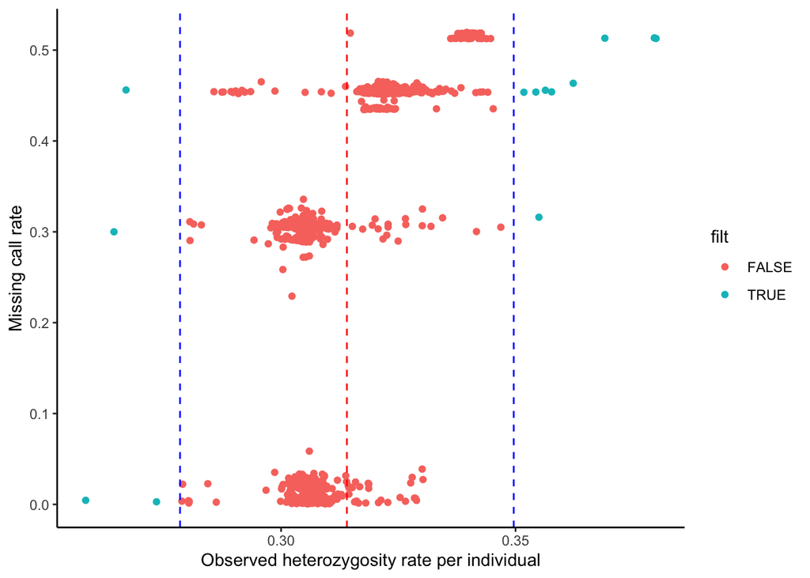

```r
d %>%
    mutate(filt = abs(Het-Het_mean) > 3*Het_SD) %>%
    ggplot() +
        geom_point(aes(x = Het, y = F_MISS, color = filt)) +
        geom_vline(xintercept = Het_mean, color = "red", linetype = "dashed") +
        geom_vline(xintercept = Het_mean-3*Het_SD, color = "blue", linetype = "dashed") +
        geom_vline(xintercept = Het_mean+3*Het_SD, color = "blue", linetype = "dashed") +
        ylab("Missing call rate") +
        xlab("Observed heterozygosity rate per individual") +
        theme_classic()
```

According to this, we should filter 13 individuals from the data, due to too low or too high heterozygosity rates.

(REMEMBER: YOU COULD SPLIT THIS INTO 4 GROUPS, EACH FOR EACH CHIP, AND THEN FILTER FOR HETEROZYGOSITY RATES.)

Now we make a file with the individuals we want to filter out.

```r
d2 %>% select(FID, IID) %>%
    write.table(file = "wrong_het_missing_values.txt", sep = "\t",
            row.names = FALSE, col.names = FALSE)
```

Now we can use the following PLINK command to remove those individuals from the data. You might want to cange –make-bed, so that you don’t overwrite the original files.

`plink --bfile eye_color --remove wrong_het_missing_values.txt --make-bed --allow-no-sex --out eyecolor-QC`

After this filtering, 13 individuals were removed from the 1,287 individuals, leaving 960,613 variants and 1,274 individuals for further filtering and quality control.

### Identification of duplicated or related individuals

#### A. Are there any closely related individuals in the sample?

We also want to filter related individuals, since they will increase the genotype frequency no matter what phenotype they have. This will result in a bias in the allele frequency distribution and eventually bias the case-control study. We therefore want to filter related individuals out of our dataset and to do this, we calculate an identity by descent (IBD) matrix. This can be done using PLINK, but it works best with non-correlated SNPs. Therefore, we prune the data such that no SNP pair has an $r^2$ value above some threshold. We do that using the following command:

`plink --bfile eyecolor-QC --indep-pairwise 500kb 5 0.2 --allow-no-sex --out eyecolor-QC`

This will output a file “eyecolor-QC.prune.in” with the independent SNPs. This file can now be used to calculate IBD between each pair of individuals. The following PLINK command is used:

`plink --bfile eyecolor-QC --extract eyecolor-QC.prune.in --genome --min 0.185 --allow-no-sex --out eyecolor-QC`

This will output a file “eyecolor-QC.genome”. The calculated IBD will only be printet in this file if it is above 0.185 (mean value between second degree relatives (0.25), and third degree relatives (0.125)). PI_HAT shows how much of the genome two individuals share. 1 = identical twins, 0.5 = siblings, 0.25 = half-siblings/uncle/aunt, 0.125 = first cousins.

```r
ibd <- read.table('eyecolor-QC.genome', header = TRUE)
ibd
```

```
##    FID1 IID1 FID2 IID2 RT EZ     Z0     Z1     Z2 PI_HAT PHE      DST PPC
## 1  1173 1173 4814 4814 UN NA 0.0000 0.0000 1.0000 1.0000  -1 1.000000   1
## 2  1269 1269 1275 1275 UN NA 0.0016 0.9596 0.0388 0.5186  -1 0.873349   1
## 3  1424 1424 6035 6035 UN NA 0.0000 0.0000 1.0000 1.0000  -1 1.000000   1
## 4  1775 1775 2083 2083 UN NA 0.0000 0.0000 1.0000 1.0000  -1 1.000000   1
## 5  2651 2651  912  912 UN NA 0.0019 0.9757 0.0225 0.5103  -1 0.871179   1
## 6  3998 3998 6191 6191 UN NA 0.0000 0.0000 1.0000 1.0000  -1 1.000000   1
## 7  4460 4460 5895 5895 UN NA 0.0000 0.0000 1.0000 1.0000  -1 1.000000   1
## 8  4547 4547 4632 4632 UN NA 0.5345 0.4655 0.0000 0.2327  -1 0.804813   1
## 9  4583 4583 4584 4584 UN NA 0.2415 0.5295 0.2290 0.4938  -1 0.879323   1
## 10 4583 4583 4585 4585 UN NA 0.4231 0.5769 0.0000 0.2885  -1 0.825543   1
## 11 4584 4584 4585 4585 UN NA 0.4168 0.5832 0.0000 0.2916  -1 0.828596   1
## 12 5792 5792 9107 9107 UN NA 0.0000 0.0000 1.0000 1.0000  -1 1.000000   1
## 13  651  651  903  903 UN NA 0.0020 0.9725 0.0255 0.5118  -1 0.871572   1
## 14 8915 8915 9486 9486 UN NA 0.0000 0.0000 1.0000 1.0000  -1 1.000000   1
```

[output cut: 17 more lines]

```r
members <- ibd$FID1
members <- unique(members)
write.table(cbind(members,members), file = 'wrong_ibd.txt', col.names = F, row.names = F)
members
```

```
##  [1] 1173 1269 1424 1775 2651 3998 4460 4547 4583 4584 5792  651 8915 9277
```

Now, to remove these individuals, we use the following command:

`plink --bfile eyecolor-QC --remove wrong_ibd.txt --make-bed --allow-no-sex --out eyecolor-QC`

After the filtering, 14 individuals were removed from the data, which means that 960,613 variants and 1,260 individuals pass filters and QC.

# SNP QC

### Identification of SNPs with an excessive missing data rate

We run the missing command again, since we have done some filtering.

`plink --bfile eyecolor-QC --missing --allow-no-sex --out eyecolor-QC`

```r
d_lmiss <- read.table("eyecolor-QC.lmiss", header = T)
head(d_lmiss)
```

```
##   CHR        SNP N_MISS N_GENO  F_MISS
## 1   1  rs4477212    618   1260 0.49050
## 2   1  rs3094315    699   1260 0.55480
## 3   1  rs3131972     41   1260 0.03254
## 4   1 rs12124819    272   1260 0.21590
## 5   1 rs11240777     35   1260 0.02778
## 6   1  rs6681049    584   1260 0.46350
```

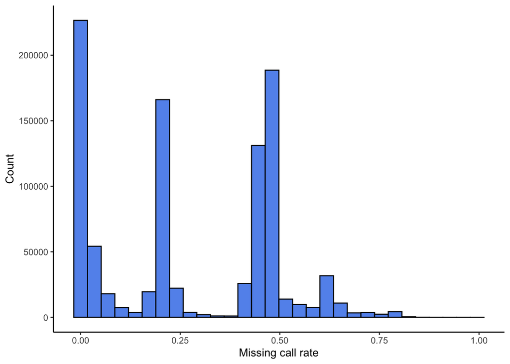

```r
d_lmiss %>%
    ggplot(aes(x=F_MISS)) +
    geom_histogram(col = "black", fill = "cornflowerblue") +
    xlab("Missing call rate") +
    ylab("Count") +
    theme_classic()
```

Here, again, we see a grouping of the different chips. We will not be doing any filtering. From now on, we will go on with the eyecolor_QC.bed/bim/fam files, since these are the files that has been subject to quality control.

We use this command to filter away variants that deviate more from HW than $p<1 \cdot 10^{-5}$. I also filter minor allele frequence of less than 0.01 and at last we filter for a call rate of 25%, which means we filter for variants that have more than 75% missing data.

`plink --bfile eyecolor-QC --geno 0.75 --hwe 0.00001 --maf 0.01 --make-bed --allow-no-sex --out eyecolor-QC`

- 8,167 variants were removed due to missing genotype data (–geno)
- 24,523 variants were removed due to Hardy-Weinberg exact test (–hwe)
- 89,770 variants were removed due to minor allele threshold(s) variants from the data (–maf).

In total 838,153 variants and 1,260 individuals pass filters and QC.

This completes the data preprocessing.

# Association testing using PLINK

## Creating a binary phenotype

Reading in the two data files:

```r
eyecolor_qc <- read.table("eyecolor-QC.fam")
colnames(eyecolor_qc) <- c("FID","IID","PAT","MAT","SEX","PHENO")
knitr::kable(head(eyecolor_qc))
```

| FID | IID | PAT | MAT | SEX | PHENO |
| --- | --- | --- | --- | --- | --- |
| 1010 | 1010 | 0 | 0 | 0 | -9 |
| 1013 | 1013 | 0 | 0 | 0 | -9 |
| 1020 | 1020 | 0 | 0 | 0 | -9 |
| 1022 | 1022 | 0 | 0 | 0 | -9 |
| 1024 | 1024 | 0 | 0 | 0 | -9 |
| 1026 | 1026 | 0 | 0 | 0 | -9 |

```r
phenotype <- read.table("eye_color.txt")
colnames(phenotype) <- c("IID", "eyecolor")
knitr::kable(head(phenotype))
```

| IID | eyecolor |
| --- | --- |
| 1010 | brown |
| 1013 | hazel/brown-green |
| 1020 | blue |
| 1022 | blue-green |
| 1024 | blue |
| 1026 | hazel/brown-green |

Visualizing the data:

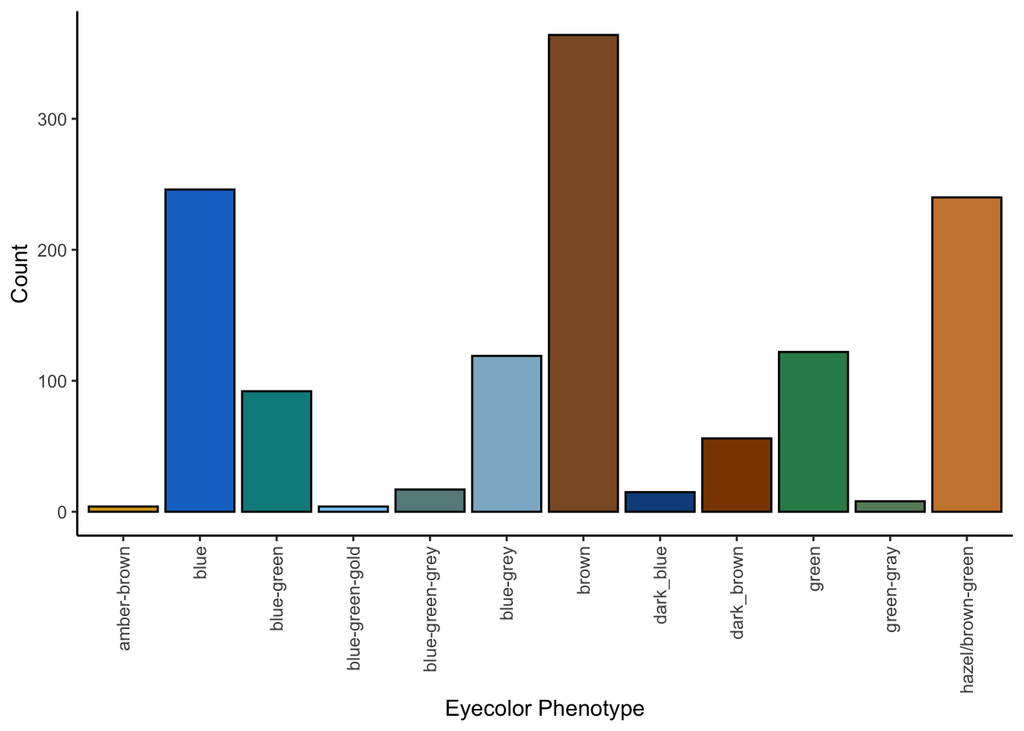

```r
ggplot(phenotype) +
    geom_bar(aes(x = eyecolor, fill = eyecolor), col = "black") +
    theme_classic() +
    theme(axis.text.x = element_text(angle = 90, vjust = 0.5, hjust=1),
          legend.position = "none") +
    xlab("Eyecolor Phenotype") + ylab("Count") +
    scale_fill_manual(values=c("goldenrod", "dodgerblue3", "cyan4", "lightskyblue", "paleturquoise4", "lightskyblue3", "tan4", "dodgerblue4", "darkorange4", "seagreen4", "darkseagreen4", "peru"))
```

I make the binary phenotypes so that 1 is all phenotypes containing the word ‘brown’, and 2 is the leftover phenotypes (green, blue, gray).

```r
phenotype$PHENO <- ifelse(grepl("brown", phenotype$eyecolor), 1 , 2)
phenotype$FID <- phenotype$IID
knitr::kable(phenotype %>% head())
```

| IID | eyecolor | PHENO | FID |
| --- | --- | --- | --- |
| 1010 | brown | 1 | 1010 |
| 1013 | hazel/brown-green | 1 | 1013 |
| 1020 | blue | 2 | 1020 |
| 1022 | blue-green | 2 | 1022 |
| 1024 | blue | 2 | 1024 |
| 1026 | hazel/brown-green | 1 | 1026 |

```r
write.table(phenotype, file = "binary_phenotypes.txt", sep = "\t", row.names = FALSE, col.names = FALSE)
```

I then match the binary phenotypes to the fam file

```r
eyecolor_qc$PHENO <- phenotype$PHENO[match(eyecolor_qc$FID, phenotype$FID)]

knitr::kable(head(eyecolor_qc))
```

| FID | IID | PAT | MAT | SEX | PHENO |
| --- | --- | --- | --- | --- | --- |
| 1010 | 1010 | 0 | 0 | 0 | 1 |
| 1013 | 1013 | 0 | 0 | 0 | 1 |
| 1020 | 1020 | 0 | 0 | 0 | 2 |
| 1022 | 1022 | 0 | 0 | 0 | 2 |
| 1024 | 1024 | 0 | 0 | 0 | 2 |
| 1026 | 1026 | 0 | 0 | 0 | 1 |

```r
knitr::kable(eyecolor_qc %>% group_by(PHENO) %>% summarise(count = n()))
```

| PHENO | count |
| --- | --- |
| 1 | 646 |
| 2 | 614 |

As we can see, there are 646 individuals with brown phenotype and 614 individuals with other phenotype

## PCA

It is best to do PCA on an LD-pruned set of SNPs. Therefore, we use the follwing command to prune the dataset:

`plink --bfile eyecolor-QC --indep-pairwise 500kb 5 0.2 --allow-no-sex --out eyecolor-QC`

This creates a “.prune.in” and a “.prune.out” file. Now, to use the pruned SNPs to calculate the first 20 PCs, we run this command:

`plink --bfile eyecolor-QC --extract eyecolor-QC.prune.in --pca 20 --allow-no-sex --out eyecolor-QC`

This calculates the eigenvalues and eigenvectors.

```r
pca <- read.table("eyecolor-QC.eigenvec")
colnames(pca) <- c(c("FID","IID"),paste(rep("PC",20),seq(1,20),sep=""))

pca <- inner_join(eyecolor_qc, pca)
knitr::kable(head(pca))
```

| FID | IID | PAT | MAT | SEX | PHENO | PC1 | PC2 | PC3 | PC4 | PC5 | PC6 | PC7 | PC8 | PC9 | PC10 | PC11 | PC12 | PC13 | PC14 | PC15 | PC16 | PC17 | PC18 | PC19 | PC20 |
| --- | --- | --- | --- | --- | --- | --- | --- | --- | --- | --- | --- | --- | --- | --- | --- | --- | --- | --- | --- | --- | --- | --- | --- | --- | --- |
| 1010 | 1010 | 0 | 0 | 0 | 1 | 0.0020207 | -0.0060927 | 0.0190543 | 0.0167434 | 0.0165428 | -0.0142887 | -0.0025644 | 0.0029546 | 0.0039499 | -0.0018023 | -0.0099895 | 0.0063961 | -0.0000472 | -0.0184659 | -0.0099412 | 0.0021603 | 0.0033157 | -0.0058192 | 0.0051827 | -0.0091176 |
| 1013 | 1013 | 0 | 0 | 0 | 1 | 0.0119961 | -0.0020294 | -0.0113486 | -0.0119712 | -0.0091683 | -0.0008155 | 0.0028037 | 0.0027797 | -0.0086928 | -0.0034449 | -0.0020703 | 0.0055283 | -0.0020684 | -0.0104623 | 0.0025157 | 0.0057167 | -0.0101091 | 0.0008462 | -0.0015638 | 0.0053916 |
| 1020 | 1020 | 0 | 0 | 0 | 2 | 0.0103106 | -0.0043945 | -0.0108394 | -0.0160057 | -0.0060668 | -0.0014429 | 0.0011523 | -0.0016512 | -0.0003497 | -0.0026531 | -0.0038992 | -0.0035868 | -0.0039629 | 0.0035298 | -0.0052615 | -0.0010610 | 0.0039131 | 0.0000613 | 0.0025115 | 0.0112497 |
| 1022 | 1022 | 0 | 0 | 0 | 2 | 0.0113773 | -0.0024433 | -0.0110404 | -0.0115308 | -0.0058822 | -0.0053048 | 0.0020627 | -0.0064923 | 0.0115284 | 0.0001440 | -0.0127485 | -0.0029617 | -0.0015659 | 0.0056370 | 0.0003903 | -0.0025185 | -0.0043827 | -0.0011521 | 0.0024866 | 0.0001291 |
| 1024 | 1024 | 0 | 0 | 0 | 2 | 0.0072326 | -0.0021232 | -0.0053385 | -0.0047300 | 0.0041680 | 0.0034250 | 0.0015788 | -0.0033870 | -0.0003972 | 0.0005456 | 0.0059658 | 0.0027724 | -0.0026104 | 0.0099983 | -0.0042770 | 0.0059014 | 0.0014650 | -0.0068291 | 0.0019384 | -0.0040482 |
| 1026 | 1026 | 0 | 0 | 0 | 1 | 0.0105154 | -0.0025705 | -0.0141648 | -0.0114772 | -0.0021185 | -0.0052690 | -0.0041842 | -0.0051879 | -0.0012408 | -0.0040268 | -0.0014594 | 0.0006525 | -0.0033680 | 0.0045106 | 0.0041662 | 0.0055679 | 0.0065645 | 0.0045364 | 0.0059122 | 0.0080585 |

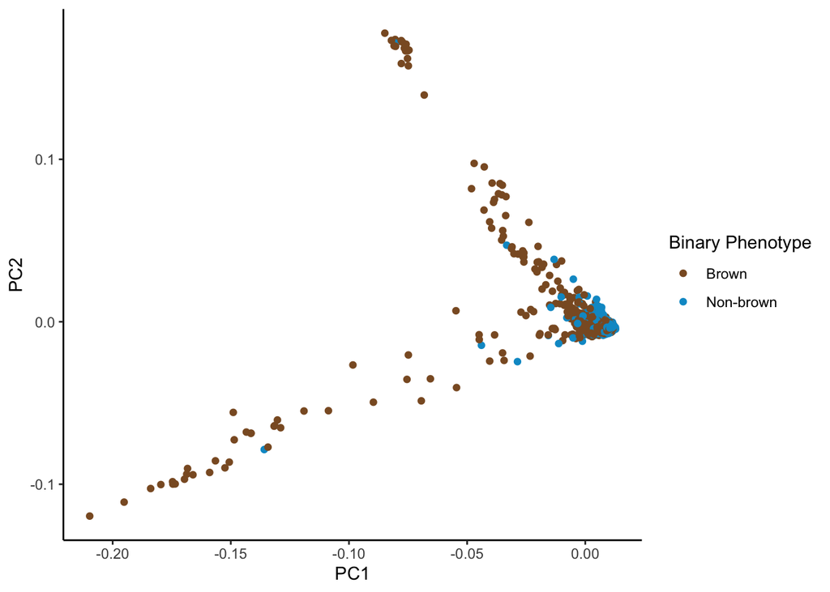

```r
pca %>% ggplot() +
    geom_point(aes( x= PC1, y = PC2, color = factor(PHENO))) +
    theme_classic() +
    scale_color_manual(values=c("tan4", "deepskyblue3"), labels = c("Brown", "Non-brown")) +
    guides(col=guide_legend("Binary Phenotype"))
```

## Fisher's Exact test

To do the Fisher’s exact test, we type the following command:

`plink --bfile eyecolor-QC --assoc fisher --allow-no-sex --pheno binary_phenotypes.txt --out eyecolor`

This produces an “eyecolor.assoc.fisher” output file, with the following:

```r
fisher <- read.table("eyecolor.assoc.fisher", header = T)

fisher <- fisher[order(fisher$P),]

knitr::kable(fisher %>% head(n = 10))
```

|  | CHR | SNP | BP | A1 | F_A | F_U | A2 | P | OR |
| --- | --- | --- | --- | --- | --- | --- | --- | --- | --- |
| 677127 | 15 | rs1667394 | 28530182 | C | 0.04570 | 0.3961 | T | 0 | 0.07302 |
| 677124 | 15 | rs916977 | 28513364 | T | 0.04520 | 0.3836 | C | 0 | 0.07608 |
| 677125 | 15 | rs8039195 | 28516084 | C | 0.04461 | 0.3511 | T | 0 | 0.08630 |
| 677110 | 15 | rs4778241 | 28338713 | A | 0.07980 | 0.3529 | C | 0 | 0.15900 |
| 677120 | 15 | rs11636232 | 28386626 | T | 0.48990 | 0.1928 | C | 0 | 4.02200 |
| 677118 | 15 | rs3935591 | 28374012 | T | 0.04062 | 0.3769 | C | 0 | 0.06999 |
| 677109 | 15 | rs4778138 | 28335820 | G | 0.06426 | 0.2852 | A | 0 | 0.17210 |
| 677111 | 15 | rs7495174 | 28344238 | G | 0.02362 | 0.1703 | A | 0 | 0.11790 |
| 677126 | 15 | rs16950987 | 28526228 | A | 0.01245 | 0.1673 | G | 0 | 0.06273 |
| 677108 | 15 | rs7174027 | 28328765 | A | 0.05065 | 0.2225 | G | 0 | 0.18650 |

```r
knitr::kable(fisher %>%
filter(P <= 5e-8) %>%
summarise(n = n()))
```

| n |
| --- |
| 749 |

After the Fisher's exact test, 749 SNPs are significant.

I then make a QQ-plot:

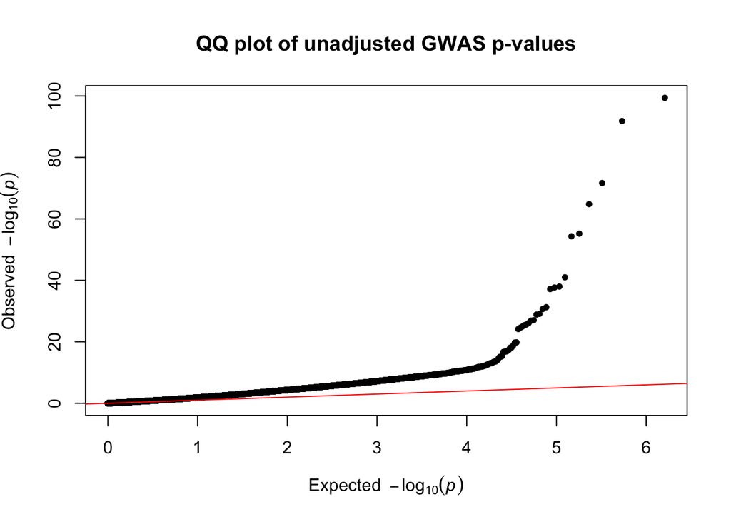

```r
qq(fisher$P, main = "QQ plot of unadjusted GWAS p-values")
```

I then try to adjust the p-values using Bonferroni correction to see if the significant loci are still significant when they have been adjusted.

```r
fisher$bonf <- p.adjust(fisher$P, method = "bonferroni", n = nrow(fisher))

knitr::kable(fisher %>% head(n = 10))
```

|  | CHR | SNP | BP | A1 | F_A | F_U | A2 | P | OR | bonf |
| --- | --- | --- | --- | --- | --- | --- | --- | --- | --- | --- |
| 677127 | 15 | rs1667394 | 28530182 | C | 0.04570 | 0.3961 | T | 0 | 0.07302 | 0 |
| 677124 | 15 | rs916977 | 28513364 | T | 0.04520 | 0.3836 | C | 0 | 0.07608 | 0 |
| 677125 | 15 | rs8039195 | 28516084 | C | 0.04461 | 0.3511 | T | 0 | 0.08630 | 0 |
| 677110 | 15 | rs4778241 | 28338713 | A | 0.07980 | 0.3529 | C | 0 | 0.15900 | 0 |
| 677120 | 15 | rs11636232 | 28386626 | T | 0.48990 | 0.1928 | C | 0 | 4.02200 | 0 |
| 677118 | 15 | rs3935591 | 28374012 | T | 0.04062 | 0.3769 | C | 0 | 0.06999 | 0 |
| 677109 | 15 | rs4778138 | 28335820 | G | 0.06426 | 0.2852 | A | 0 | 0.17210 | 0 |
| 677111 | 15 | rs7495174 | 28344238 | G | 0.02362 | 0.1703 | A | 0 | 0.11790 | 0 |
| 677126 | 15 | rs16950987 | 28526228 | A | 0.01245 | 0.1673 | G | 0 | 0.06273 | 0 |
| 677108 | 15 | rs7174027 | 28328765 | A | 0.05065 | 0.2225 | G | 0 | 0.18650 | 0 |

```r
knitr::kable(fisher %>%
filter(bonf <= 5e-8) %>%
summarise(n = n()))
```

| n |
| --- |
| 42 |

After Bonferroni correction, there are only 42 significant loci. But the ten most significant loci are still the same.

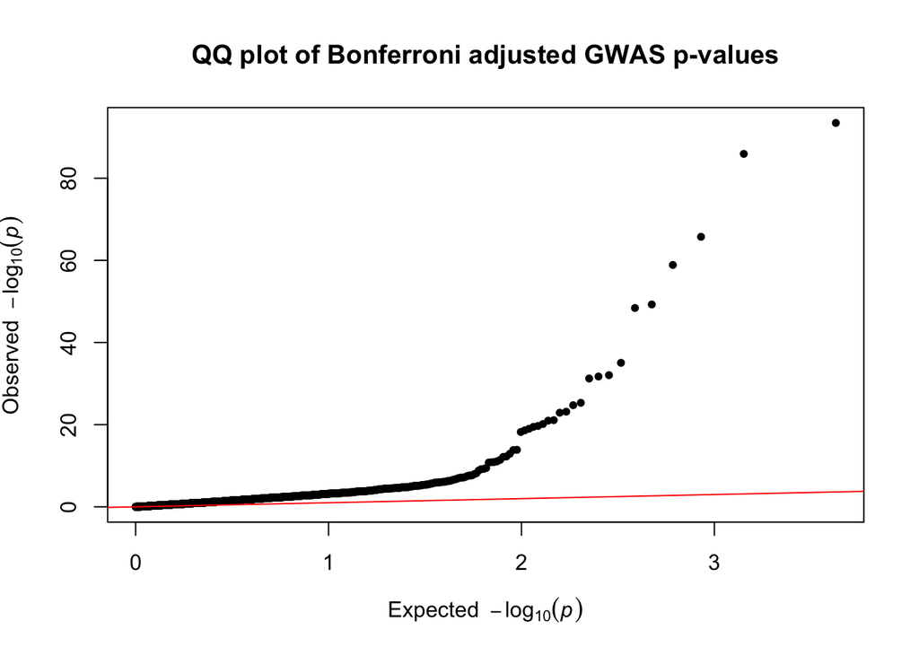

```r
qq(fisher$bonf, main = "QQ plot of Bonferroni adjusted GWAS p-values")
```

There are no longer as many significant SNPs, however the data still seems inflated. This can be corrected in two ways: Either doing genomic control or adjusting for PCs.

## Genomic control

The inflation factor (𝝺) can be calculated as the median of the Chi-squared statistics computed divided by the median of the Chi-squared distribution under the null. Given a p-value (p) the corresponding Chi-squared quantile can be calculated as:

qchisq(p, df=1, lower.tail = F)

To do genomic control (to adjust for inflated test statistic) you divide the Chi-squared values by the inflation factor. To turn a Chi-squared quantile (q) into a p-value you use the “pchisq” function:

pchisq(q, df=1, lower.tail = F)

First we calculate the median of the chi-squared distribution under the null:

```r
set.seed(0)
exp_med <- median(rchisq(10000000,1))
exp_med
```

```
## [1] 0.4550127
```

Then we calculate the observed chi-squared statistics:

```r
fisher <- fisher %>% mutate(obs_qchisq = qchisq(P, df=1, lower.tail = F))
knitr::kable(head(fisher))
```

|  | CHR | SNP | BP | A1 | F_A | F_U | A2 | P | OR | bonf | obs_qchisq |
| --- | --- | --- | --- | --- | --- | --- | --- | --- | --- | --- | --- |
| 677127 | 15 | rs1667394 | 28530182 | C | 0.04570 | 0.3961 | T | 0 | 0.07302 | 0 | 451.0945 |
| 677124 | 15 | rs916977 | 28513364 | T | 0.04520 | 0.3836 | C | 0 | 0.07608 | 0 | 416.4666 |
| 677125 | 15 | rs8039195 | 28516084 | C | 0.04461 | 0.3511 | T | 0 | 0.08630 | 0 | 323.7804 |
| 677110 | 15 | rs4778241 | 28338713 | A | 0.07980 | 0.3529 | C | 0 | 0.15900 | 0 | 292.2826 |
| 677120 | 15 | rs11636232 | 28386626 | T | 0.48990 | 0.1928 | C | 0 | 4.02200 | 0 | 248.1935 |
| 677118 | 15 | rs3935591 | 28374012 | T | 0.04062 | 0.3769 | C | 0 | 0.06999 | 0 | 244.2429 |

The we calculate the inflation factor:

```r
lambda <- median(fisher$obs_qchisq)/exp_med
lambda
```

```
## [1] 1.967189
```

At last we calculate the corrected p-values using the inflation factor and make a QQ-plot again with the inflation corrected p-values:

```r
fisher <- fisher %>%
mutate(corrected_qchisq = obs_qchisq/lambda) %>%
mutate(corrected_p = pchisq(corrected_qchisq, df=1, lower.tail = F))
knitr::kable(head(fisher))
```

|  | CHR | SNP | BP | A1 | F_A | F_U | A2 | P | OR | bonf | obs_qchisq | corrected_qchisq | corrected_p |
| --- | --- | --- | --- | --- | --- | --- | --- | --- | --- | --- | --- | --- | --- |
| 677127 | 15 | rs1667394 | 28530182 | C | 0.04570 | 0.3961 | T | 0 | 0.07302 | 0 | 451.0945 | 229.3091 | 0 |
| 677124 | 15 | rs916977 | 28513364 | T | 0.04520 | 0.3836 | C | 0 | 0.07608 | 0 | 416.4666 | 211.7064 | 0 |
| 677125 | 15 | rs8039195 | 28516084 | C | 0.04461 | 0.3511 | T | 0 | 0.08630 | 0 | 323.7804 | 164.5904 | 0 |
| 677110 | 15 | rs4778241 | 28338713 | A | 0.07980 | 0.3529 | C | 0 | 0.15900 | 0 | 292.2826 | 148.5788 | 0 |
| 677120 | 15 | rs11636232 | 28386626 | T | 0.48990 | 0.1928 | C | 0 | 4.02200 | 0 | 248.1935 | 126.1665 | 0 |
| 677118 | 15 | rs3935591 | 28374012 | T | 0.04062 | 0.3769 | C | 0 | 0.06999 | 0 | 244.2429 | 124.1583 | 0 |

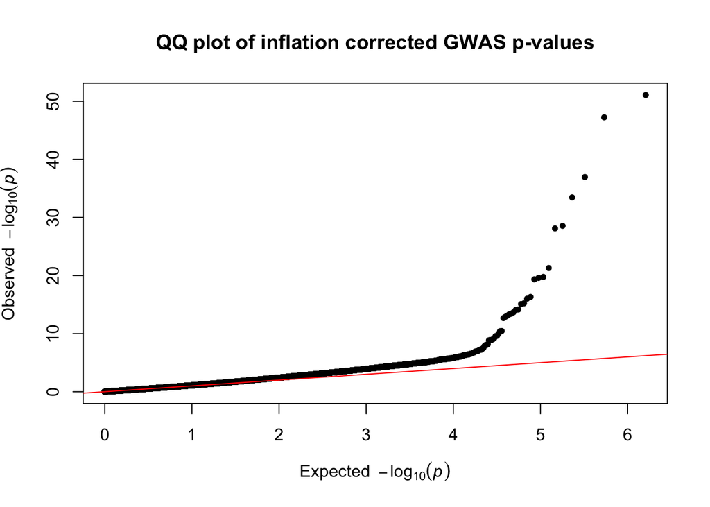

```r
qq(fisher$corrected_p, main = "QQ plot of inflation corrected GWAS p-values")
```

As we can see from the QQ-plot above, using genomic control to correct for inflation did help a bit on the inflation.

## Adjusting for PCs

In order to know how many PCs we have to adjust for, I first calculate how much variance that is explained by each PC.

```r
eigenval <- read.table("eyecolor-QC.eigenval", header = F)

eigenval <- eigenval %>%
    mutate(variance_expl = V1/sum(V1)*100) %>%
    mutate(PC = seq(1,20)) %>%
    mutate(cumsum = cumsum(variance_expl))

knitr::kable(head(eigenval))
```

| V1 | variance_expl | PC | cumsum |
| --- | --- | --- | --- |
| 26.41120 | 35.696730 | 1 | 35.69673 |
| 12.33450 | 16.671008 | 2 | 52.36774 |
| 3.14379 | 4.249069 | 3 | 56.61681 |
| 2.83093 | 3.826215 | 4 | 60.44302 |
| 2.26759 | 3.064819 | 5 | 63.50784 |
| 2.20035 | 2.973939 | 6 | 66.48178 |

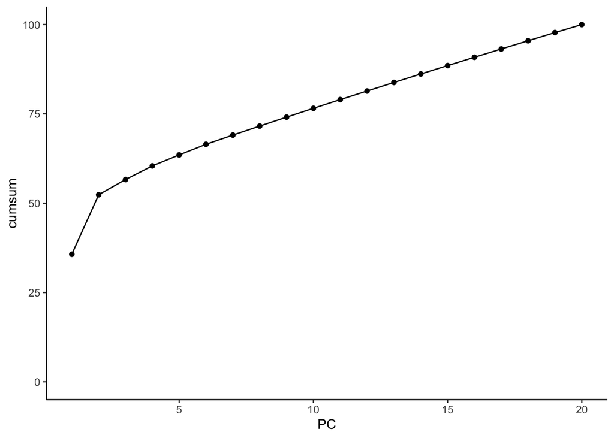

```r
eigenval %>%
    ggplot() +
        geom_line(aes(x = PC, y = cumsum)) +
        geom_point(aes(x = PC, y = cumsum)) +
        ylim(0,100) +
        theme_classic()
```

From the above, we see that the two first PCs explain over 50% of the variance. Therefore, we only need to adjust for these two.

We can use logistic regression test to perform an association test while correcting for covariates. To include the first 2 PCs as a covariate we type:

`plink --bfile eyecolor-QC --pheno binary_phenotypes.txt --allow-no-sex --logistic --covar eyecolor-QC.eigenvec --covar-number 1-2`

The output file plink.assoc.logistic contains p-values for both the SNPs and the covariates.

```r
logistic <- read.table("plink.assoc.logistic", header = T)

logistic <- logistic %>%
    filter(TEST == "ADD") %>%
    filter(!(is.na(P))) %>%
    arrange(P)

knitr::kable(head(logistic))
```

| CHR | SNP | BP | A1 | TEST | NMISS | OR | STAT | P |
| --- | --- | --- | --- | --- | --- | --- | --- | --- |
| 15 | rs1667394 | 28530182 | C | ADD | 1145 | 0.06814 | -15.58 | 0 |
| 15 | rs916977 | 28513364 | T | ADD | 1109 | 0.07666 | -14.71 | 0 |
| 15 | rs8039195 | 28516084 | C | ADD | 999 | 0.08342 | -13.41 | 0 |
| 15 | rs4778241 | 28338713 | A | ADD | 1260 | 0.16480 | -13.28 | 0 |
| 15 | rs11636232 | 28386626 | T | ADD | 1234 | 3.44600 | 11.84 | 0 |
| 15 | rs3935591 | 28374012 | T | ADD | 641 | 0.06689 | -11.33 | 0 |

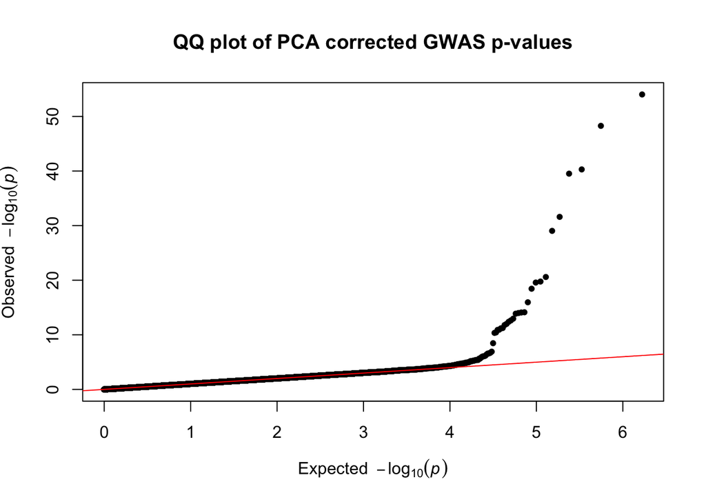

```r
qq(logistic$P, main = "QQ plot of PCA corrected GWAS p-values")
```

I once again calculate the inflation factor to see if it has improved (i.e., if it is closer to 1).

```r
logistic <- logistic %>%
    mutate(obs_q = qchisq(P, df=1, lower.tail = F))

lambda <- median(logistic$obs_q)/exp_med
lambda
```

```
## [1] 1.02383
```

As we can see both from the QQ plot and the inflation factor, the PCA correction is effective and therefore this is what I am going to be using when making the manhattan plot.

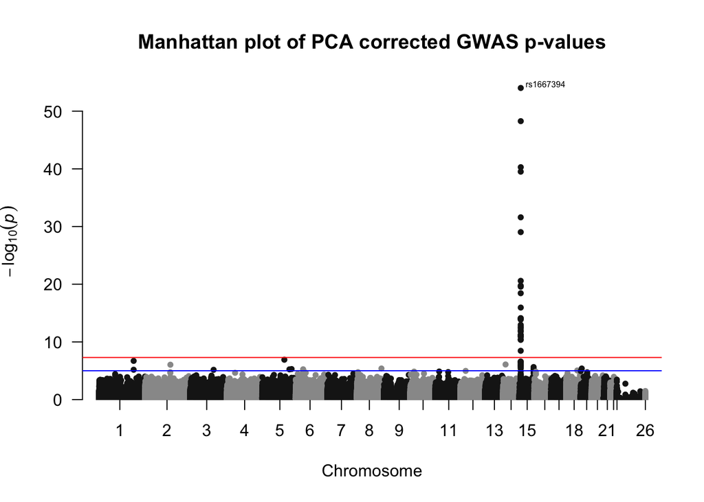

```r
manhattan(logistic, main = "Manhattan plot of PCA corrected GWAS p-values", annotatePval = 5e-8)
```

If we use a significance threshold of 5e-8 (the red line in the manhattan plot), we get the following significant SNPs:

```r
significant <- logistic %>%
    filter(P<=5e-8) %>%
    arrange(P)

knitr::kable(significant)
```

| CHR | SNP | BP | A1 | TEST | NMISS | OR | STAT | P | obs_q |
| --- | --- | --- | --- | --- | --- | --- | --- | --- | --- |
| 15 | rs1667394 | 28530182 | C | ADD | 1145 | 0.06814 | -15.580 | 0 | 242.82842 |
| 15 | rs916977 | 28513364 | T | ADD | 1109 | 0.07666 | -14.710 | 0 | 216.45211 |
| 15 | rs8039195 | 28516084 | C | ADD | 999 | 0.08342 | -13.410 | 0 | 179.88844 |
| 15 | rs4778241 | 28338713 | A | ADD | 1260 | 0.16480 | -13.280 | 0 | 176.33223 |
| 15 | rs11636232 | 28386626 | T | ADD | 1234 | 3.44600 | 11.840 | 0 | 140.11205 |
| 15 | rs3935591 | 28374012 | T | ADD | 641 | 0.06689 | -11.330 | 0 | 128.38246 |
| 15 | rs4778138 | 28335820 | G | ADD | 1031 | 0.22380 | -9.478 | 0 | 89.83709 |
| 15 | rs7183877 | 28365733 | A | ADD | 1260 | 0.17020 | -9.276 | 0 | 86.04823 |
| 15 | rs7495174 | 28344238 | G | ADD | 1260 | 0.14030 | -9.231 | 0 | 85.20486 |
| 15 | rs7174027 | 28328765 | A | ADD | 1257 | 0.24420 | -8.947 | 0 | 80.05734 |
| 15 | rs16950987 | 28526228 | A | ADD | 999 | 0.07551 | -8.292 | 0 | 68.75833 |
| 15 | rs8024968 | 28283689 | T | ADD | 1260 | 0.34700 | -7.776 | 0 | 60.46470 |
| 15 | rs4778232 | 28281765 | T | ADD | 1259 | 0.45840 | -7.764 | 0 | 60.27592 |
| 15 | rs16950821 | 28283507 | A | ADD | 1260 | 0.34900 | -7.734 | 0 | 59.81701 |
| 15 | rs1597196 | 28294922 | T | ADD | 1258 | 0.43370 | -7.701 | 0 | 59.30840 |
| 15 | rs12593929 | 28359258 | G | ADD | 704 | 0.07693 | -7.427 | 0 | 55.15659 |
| 15 | rs6497287 | 28440287 | C | ADD | 680 | 0.14650 | -7.328 | 0 | 53.69717 |
| 15 | rs7170869 | 28288748 | G | ADD | 999 | 0.37750 | -7.249 | 0 | 52.54594 |
| 15 | rs3794604 | 28272065 | T | ADD | 1235 | 0.38170 | -7.130 | 0 | 50.83239 |
| 15 | rs6497253 | 28288549 | A | ADD | 999 | 0.44620 | -7.062 | 0 | 49.87331 |
| 15 | rs1375164 | 28291812 | T | ADD | 963 | 0.45050 | -6.886 | 0 | 47.41642 |
| 15 | rs8028689 | 28488888 | C | ADD | 739 | 0.08281 | -6.868 | 0 | 47.17540 |
| 15 | rs2240203 | 28494202 | C | ADD | 672 | 0.08447 | -6.787 | 0 | 46.05977 |
| 15 | rs16950993 | 28532120 | G | ADD | 688 | 0.08528 | -6.773 | 0 | 45.86793 |
| 15 | rs7179994 | 28323770 | G | ADD | 1259 | 0.45360 | -6.617 | 0 | 43.79090 |
| 15 | rs749846 | 28268990 | A | ADD | 999 | 0.41630 | -6.588 | 0 | 43.40302 |
| 15 | rs7177686 | 28287344 | A | ADD | 667 | 0.44920 | -5.907 | 0 | 34.89429 |

27 SNPs are significant after PCA correction using a threshold of 5e-8. All 27 SNPs are found on Chr 15.

# Zooming in on the SNPs at the most significant loci

I use this funtion to compute the genotypes for the SNPs, with a window around 200 kb:

`plink --bfile eyecolor-QC --pheno binary_phenotypes.txt --allow-no-sex --recode A --snp rs1667394 --window 200 --out SNP`

```r
genotypes <- read.table("SNP.raw", header = T)

genotypes$PHENO <- eyecolor_qc$PHENO
genotypes$PHENO <- ifelse(genotypes$PHENO == 1, "brown", "non-brown")

knitr::kable(head(genotypes))
```

| FID | IID | PAT | MAT | SEX | PHENOTYPE | rs6497287_C | rs8028689_C | rs2240203_C | rs916977_T | rs8039195_C | rs16950987_A | rs1667394_C | rs16950993_G | rs1667400_A | PHENO |
| --- | --- | --- | --- | --- | --- | --- | --- | --- | --- | --- | --- | --- | --- | --- | --- |
| 1010 | 1010 | 0 | 0 | 0 | 1 | NA | 0 | NA | NA | 0 | 0 | 1 | NA | NA | brown |
| 1013 | 1013 | 0 | 0 | 0 | 1 | 1 | 0 | 0 | 1 | 1 | 0 | 1 | 0 | 0 | brown |
| 1020 | 1020 | 0 | 0 | 0 | 2 | 0 | 0 | 0 | 0 | 0 | 0 | 0 | 0 | 0 | non-brown |
| 1022 | 1022 | 0 | 0 | 0 | 2 | 0 | 0 | 0 | 0 | 0 | 0 | 0 | 0 | 0 | non-brown |
| 1024 | 1024 | 0 | 0 | 0 | 2 | 0 | 0 | 0 | 0 | 0 | 0 | 0 | 0 | 0 | non-brown |
| 1026 | 1026 | 0 | 0 | 0 | 1 | 0 | 0 | 0 | 0 | 0 | 0 | 0 | 0 | 0 | brown |

```r
eye_col <- phenotype %>%
    filter(!(IID %in% members)) %>%
    filter(!(IID %in% het_filter))

most_sig <- genotypes %>%
    select(matches('rs1667394')) %>%
    mutate(response = factor(eye_col$PHENO)) %>%
    mutate(eye_col = eye_col$eyecolor)  %>%
    drop_na()

knitr::kable(head(most_sig))
```

| rs1667394_C | response | eye_col |
| --- | --- | --- |
| 1 | 1 | brown |
| 1 | 1 | hazel/brown-green |
| 0 | 2 | blue |
| 0 | 2 | blue-green |
| 0 | 2 | blue |
| 0 | 1 | hazel/brown-green |

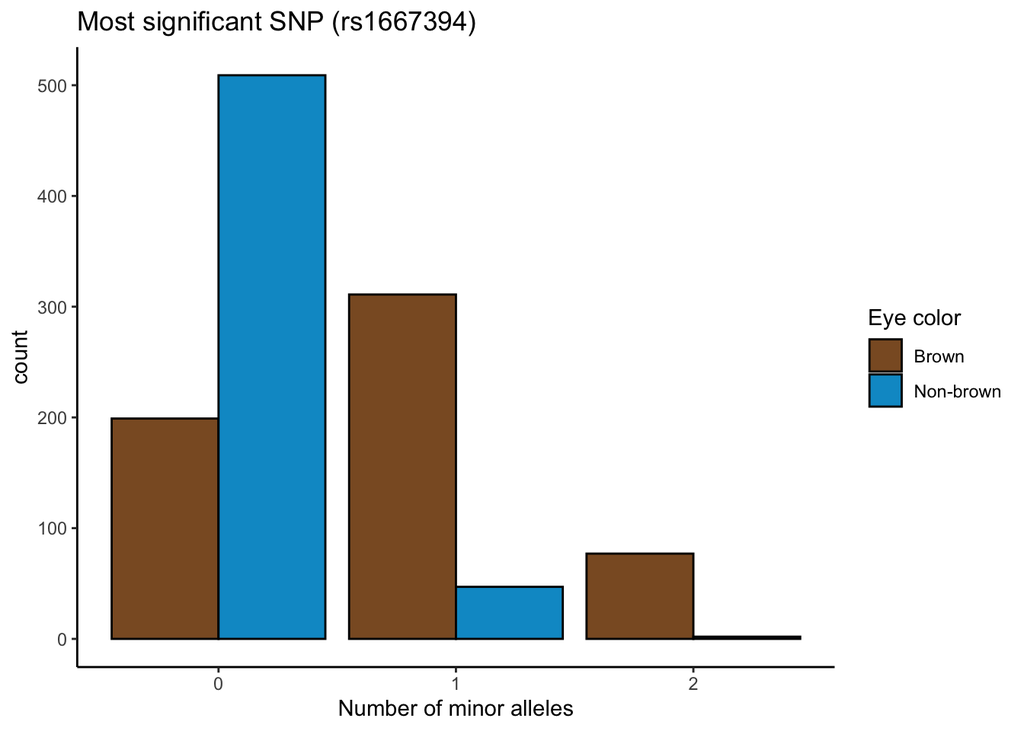

```r
ggplot(data = most_sig, aes(x = rs1667394_C, y = ..count..)) +
    geom_bar(aes(fill = response), col = "black", position = "dodge") +
    ggtitle('Most significant SNP (rs1667394)') +
    xlab("Number of minor alleles") +
    scale_fill_manual(values = c("tan4", "deepskyblue3"), labels = c("Brown", "Non-brown"), name = "Eye color") +
    theme_classic()
```

Here we can see that genotype 00 can result in both the brown and non-brown phenotype but mostly non-brown. Same with genotype 01 which mostly result in brown phenotype. However, genotype 11 almost only result in brown phenotype.

- Dominant: ‘AA + AB’ versus ‘BB’
- Recessive: ‘AA’ versus ‘AB + BB’
- Additive: ‘AA’ versus ‘AB’ versus ‘BB’

Here we see a plot of the most significant SNP (rs1667394) and the number of minor alleles (i.e., the number of derived alleles) for each individual for each phenotype.

```r
group <- most_sig %>%
    group_by(rs1667394_C, response, eye_col) %>%
    summarise(n = n())
```

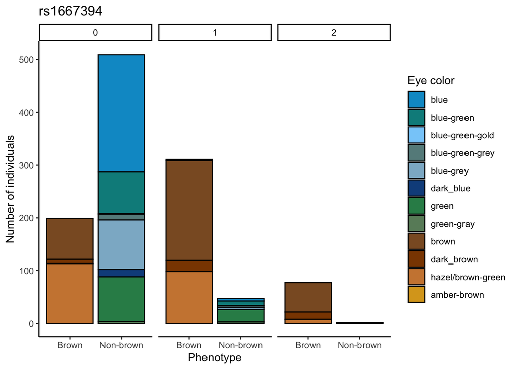

```r
colors <- c("blue"= "deepskyblue3",
            "blue-green" = "cyan4",
            "blue-green-gold" = "lightskyblue",
            "blue-green-grey" = "paleturquoise4",
            "blue-grey" = "lightskyblue3",
            "dark_blue" = "dodgerblue4",
            "green" = "seagreen4",
            "green-gray" = "darkseagreen4",
            "brown" = "tan4",
            "dark_brown" = "darkorange4",
            "hazel/brown-green" = "peru",
            "amber-brown" = "goldenrod")

levels(colors) <- c("dark_blue", "blue", "blue-green-gold", "blue-green-grey",
                   "blue-grey", "blue-green", "green", "green-gray", "brown",
                   "dark_brown", "amber-brown", "hazel/brown-green")

ggplot(data = group, aes(x = response, y = n, fill = eye_col)) +
    geom_bar(stat="identity", col = "black") +
    labs(title = 'rs1667394', y = "Number of individuals", x = "Phenotype") +
    facet_wrap(~ rs1667394_C, scales = "free_x") +
    scale_fill_manual(values = colors, name = "Eye color") +
    scale_x_discrete(labels = c("Brown", "Non-brown")) +
    theme_classic()
```

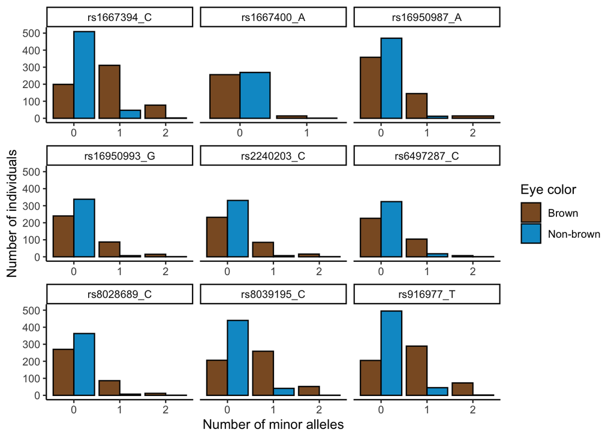

```r
data_long <- tidyr::gather(genotypes, key = variable, value = value, -c(FID, IID, PAT, MAT, SEX, PHENOTYPE, PHENO)) %>%
    drop_na()

ggplot(data_long, aes(x = factor(value), fill = factor(PHENOTYPE))) +
    geom_bar(position = "dodge", col = "black") +
    facet_wrap(~ variable, scales = "free_x", nrow = 3) +
    xlab("Number of minor alleles") +
    ylab("Number of individuals") +
    theme_classic() +
    scale_fill_manual(values = c("tan4", "deepskyblue3"), labels = c("Brown", "Non-brown"), name = "Eye color")
```

```r
significant$GENE <-c("HERC2", "HERC2", "HERC2", "OCA2", "HERC2", "HERC2", "OCA2", "HERC2", "OCA2", "OCA2", "HERC2", "OCA2", "OCA2", "OCA2", "OCA2", "HERC2", "HERC2", "OCA2", "OCA2", "OCA2", "OCA2", "HERC2", "HERC2", "HERC2", "OCA2", "OCA2", "OCA2")
knitr::kable(head(significant))
```

| CHR | SNP | BP | A1 | TEST | NMISS | OR | STAT | P | obs_q | GENE |
| --- | --- | --- | --- | --- | --- | --- | --- | --- | --- | --- |
| 15 | rs1667394 | 28530182 | C | ADD | 1145 | 0.06814 | -15.58 | 0 | 242.8284 | HERC2 |
| 15 | rs916977 | 28513364 | T | ADD | 1109 | 0.07666 | -14.71 | 0 | 216.4521 | HERC2 |
| 15 | rs8039195 | 28516084 | C | ADD | 999 | 0.08342 | -13.41 | 0 | 179.8884 | HERC2 |
| 15 | rs4778241 | 28338713 | A | ADD | 1260 | 0.16480 | -13.28 | 0 | 176.3322 | OCA2 |
| 15 | rs11636232 | 28386626 | T | ADD | 1234 | 3.44600 | 11.84 | 0 | 140.1121 | HERC2 |
| 15 | rs3935591 | 28374012 | T | ADD | 641 | 0.06689 | -11.33 | 0 | 128.3825 | HERC2 |

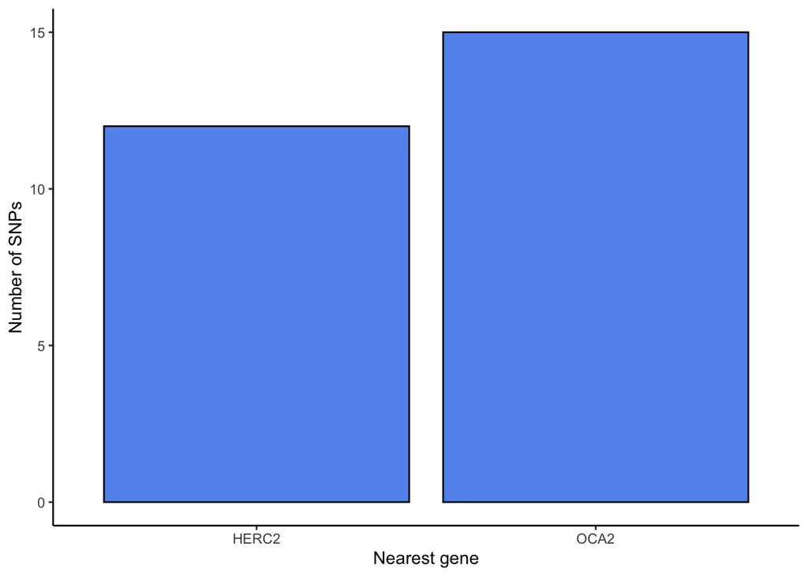

```r
significant %>%
    ggplot() +
    geom_histogram(aes(x=factor(GENE)), stat = "count", col = "black", fill = "cornflowerblue") +
    theme_classic() +
    xlab("Nearest gene") +
    ylab("Number of SNPs")
```

# Replication of paper SNPs

```r
article_genes <- read.table("article_genes.csv", sep = ";", header = T)
knitr::kable(head(article_genes))
```

| Region | Chr | Pos | RS | Nearest.Gene | Ref.Allele | Freq | Beta | SE | P |
| --- | --- | --- | --- | --- | --- | --- | --- | --- | --- |
| 1 | 1 | 9166344 | rs6693258 | GPR157 | T | 0,216 | -0,056 | 0,0091 | 9,86E-10 |
| 2 | 1 | 42110888 | rs6696511 | HIVEP3 | T | 0,382 | 0,109 | 0,0077 | 1,35E-45 |
| 3 | 1 | 212421629 | rs351385 | DTL | G | 0,58 | -0,083 | 0,0075 | 2,31E-28 |
| 4 | 1 | 236035805 | rs2385028 | LYST | T | 0,245 | 0,061 | 0,0086 | 2,43E-12 |
| 5 | 2 | 46233381 | rs13016869 | PRKCE | G | 0,208 | -0,058 | 0,0092 | 2,23E-10 |
| 6 | 2 | 206950236 | rs112747614 | INO80D | G | 0,696 | 0,054 | 0,0081 | 3,69E-11 |

```r
chromosomes <- tibble(Chr = 15,
                      size = c(102531392))

OCA2 <- tibble(Chr = 15,
               start = 28000021,
               end = 28344461,
               name = "OCA2")

HERC2 <- tibble(Chr = 15,
                start = 28356186,
                end = 28567325,
                name = "HERC2")
```

First, I try to identify SNPs which are directly found in the article.

```r
article_SNPs <- as.vector(article_genes$RS)

identical <- significant %>%
    filter(SNP %in% article_SNPs)

knitr::kable(identical)
```

| CHR | SNP | BP | A1 | TEST | NMISS | OR | STAT | P | obs_q | GENE |
| --- | --- | --- | --- | --- | --- | --- | --- | --- | --- | --- |
| 15 | rs1667394 | 28530182 | C | ADD | 1145 | 0.06814 | -15.580 | 0 | 242.82842 | HERC2 |
| 15 | rs12593929 | 28359258 | G | ADD | 704 | 0.07693 | -7.427 | 0 | 55.15659 | HERC2 |
| 15 | rs749846 | 28268990 | A | ADD | 999 | 0.41630 | -6.588 | 0 | 43.40302 | OCA2 |

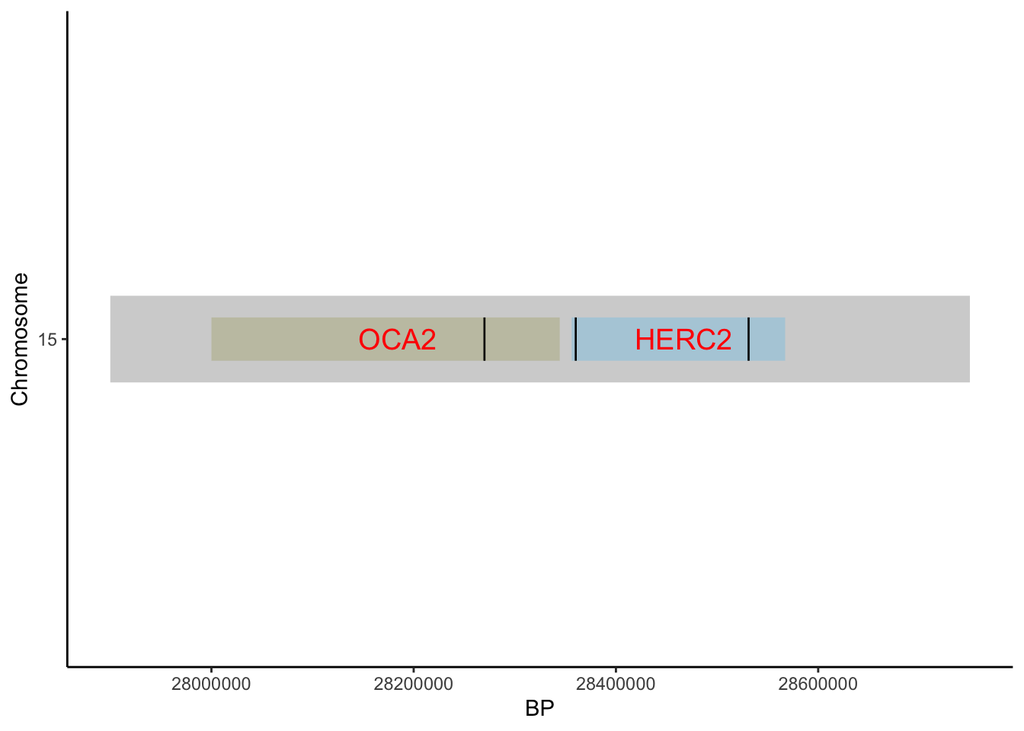

```r
p <- ggplot() +
    geom_segment(data = chromosomes, aes(x = factor(Chr), xend = factor(Chr), y = 27900000, yend = 28750000), color = "lightgrey", size = 20) +
    geom_segment(data = OCA2, aes(x = factor(Chr), xend = factor(Chr), y = start, yend = end), color = "yellow4", alpha = 0.2, size = 10) +
    geom_segment(data = HERC2, aes(x = factor(Chr), xend = factor(Chr), y = start, yend = end), color = "deepskyblue", alpha = 0.2, size = 10) +
    annotate("text", label =HERC2$name, x =factor(HERC2$Chr), y = HERC2$end-100000, size = 5, colour= "red") +
    annotate("text", label =OCA2$name, x =factor(OCA2$Chr), y = OCA2$end-160000, size = 5, colour= "red") +
    theme_classic() +
    coord_flip() +
    xlab("Chromosome") +
    ylab("BP")


p + geom_segment(data = identical, aes(x = factor(CHR), xend = factor(CHR), y = BP, yend = BP+2000), color = "black", size = 10)
```

Now I want to try to investigate if any of the SNPs i’ve found, is in close proximity to the ones in the article.

```r
find_close_genes <- function(x_away){

    sign_SNPs <- significant %>%
        mutate(ref_closest = NA,
               ref_pos = NA,
               ref_Nearest.Gene = NA,
               ref_P = NA)

    gene_pos <- tibble(Pos = article_genes$Pos,
                       Chr = article_genes$Chr,
                       RS = article_genes$RS,
                       Nearest.Gene = article_genes$Nearest.Gene,
                       P = article_genes$P)

    for (i in 1:nrow(sign_SNPs)) {

        pos <- sign_SNPs$BP[i]
        chr <- sign_SNPs$CHR[i]
        test <- gene_pos$Chr == chr & gene_pos$Pos-x_away <= pos & pos <= gene_pos$Pos+x_away

        close_rs <- gene_pos$RS[which(test)]
        ref_pos <- gene_pos$Pos[which(test)]
        gene <- gene_pos$Nearest.Gene[which(test)]
        p_val <- gene_pos$P[which(test)]

        sign_SNPs$ref_closest[i] <- list(close_rs)
        sign_SNPs$ref_pos[i] <- unique(ref_pos)[1]
        sign_SNPs$ref_Nearest.Gene[i] <- list(unique(gene))
        sign_SNPs$ref_P[i] <- list(unique(p_val))

    }

    sign_SNPs <- sign_SNPs %>%
        drop_na()

    return(sign_SNPs)
}
```

```r
bp_1000 <- find_close_genes(1000)
knitr::kable(head(bp_1000))
```

| CHR | SNP | BP | A1 | TEST | NMISS | OR | STAT | P | obs_q | GENE | ref_closest | ref_pos | ref_Nearest.Gene | ref_P |
| --- | --- | --- | --- | --- | --- | --- | --- | --- | --- | --- | --- | --- | --- | --- |
| 15 | rs1667394 | 28530182 | C | ADD | 1145 | 0.06814 | -15.580 | 0 | 242.82842 | HERC2 | rs1667394 | 28530182 | HERC2 | <1E-330 |
| 15 | rs4778241 | 28338713 | A | ADD | 1260 | 0.16480 | -13.280 | 0 | 176.33223 | OCA2 | rs4778239 | 28337939 | OCA2 | <1E-330 |
| 15 | rs7174027 | 28328765 | A | ADD | 1257 | 0.24420 | -8.947 | 0 | 80.05734 | OCA2 | rs4778137 , rs151090307 | 28327835 | OCA2 | <1E-330 , 6,20E-164 |
| 15 | rs12593929 | 28359258 | G | ADD | 704 | 0.07693 | -7.427 | 0 | 55.15659 | HERC2 | rs12593929 | 28359258 | HERC2 | <1E-330 |
| 15 | rs7170869 | 28288748 | G | ADD | 999 | 0.37750 | -7.249 | 0 | 52.54594 | OCA2 | rs1470608 | 28288121 | OCA2 | <1E-330 |
| 15 | rs6497253 | 28288549 | A | ADD | 999 | 0.44620 | -7.062 | 0 | 49.87331 | OCA2 | rs1470608 | 28288121 | OCA2 | <1E-330 |

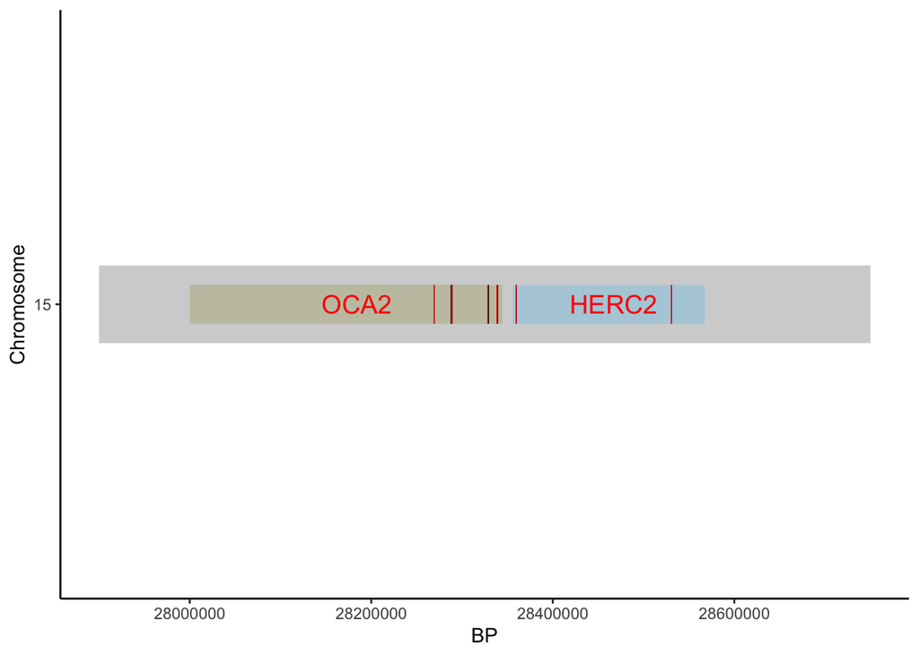

```r
p + geom_segment(data = bp_1000, aes(x = factor(CHR), xend = factor(CHR), y = BP, yend = BP+1000), color = "black", size = 10) + geom_segment(data = bp_1000, aes(x = factor(CHR), xend = factor(CHR), y = ref_pos, yend = ref_pos+1000), color = "red", size = 10)
```

```r
bp_10000 <- find_close_genes(10000)
knitr::kable(head(bp_10000))
```

| CHR | SNP | BP | A1 | TEST | NMISS | OR | STAT | P | obs_q | GENE | ref_closest | ref_pos | ref_Nearest.Gene | ref_P |
| --- | --- | --- | --- | --- | --- | --- | --- | --- | --- | --- | --- | --- | --- | --- |
| 15 | rs1667394 | 28530182 | C | ADD | 1145 | 0.06814 | -15.580 | 0 | 242.82842 | HERC2 | rs1667394 | 28530182 | HERC2 | <1E-330 |
| 15 | rs4778241 | 28338713 | A | ADD | 1260 | 0.16480 | -13.280 | 0 | 176.33223 | OCA2 | rs151090307, rs77542847 , rs76415938 , rs4778239 , rs8026089 | 28329346 | OCA2 | 6,20E-164, <1E-330 |
| 15 | rs11636232 | 28386626 | T | ADD | 1234 | 3.44600 | 11.840 | 0 | 140.11205 | HERC2 | rs150287021, rs12901047 | 28384534 | HERC2 | <1E-330 |
| 15 | rs4778138 | 28335820 | G | ADD | 1031 | 0.22380 | -9.478 | 0 | 89.83709 | OCA2 | rs4778137 , rs151090307, rs77542847 , rs76415938 , rs4778239 , rs8026089 | 28327835 | OCA2 | <1E-330 , 6,20E-164 |
| 15 | rs7183877 | 28365733 | A | ADD | 1260 | 0.17020 | -9.276 | 0 | 86.04823 | HERC2 | rs1129038 , rs77854840, rs12593929 | 28356859 | HERC2 | <1E-330 |
| 15 | rs7495174 | 28344238 | G | ADD | 1260 | 0.14030 | -9.231 | 0 | 85.20486 | OCA2 | rs4778239 , rs8026089 , rs59138695 | 28337939 | OCA2 | <1E-330 |

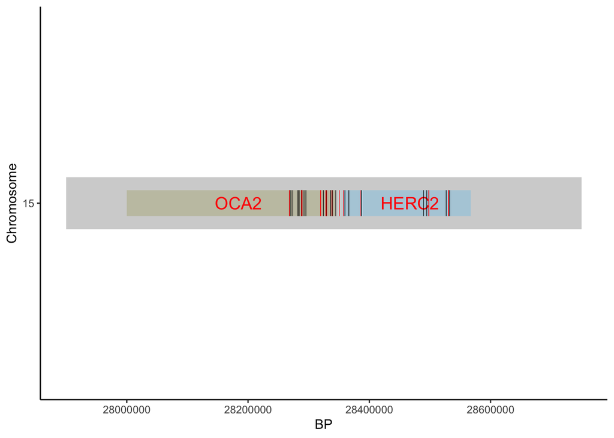

```r
p +
    geom_segment(data = bp_10000, aes(x = factor(CHR), xend = factor(CHR), y = BP, yend = BP+1000), color = "black", size = 10) +
    geom_segment(data = bp_10000, aes(x = factor(CHR), xend = factor(CHR), y = ref_pos, yend = ref_pos+1000), color = "red", size = 10)
```